# Buzzoni D., Cunning R. and Baker A. C. (2021) Initial Algal Symbiont Communities Affect Shuffling to Durusdinium after Coral Bleaching and Reflect Seasonal Differences in Bleaching Sensitivity

```r
ssidsensitivity<-subset(blch_sensitivity,Species=='S.siderea')
ssidblchresmod=glmer(post_sh~Batch+InitialDom+(1|Colony),data=ssidsensitivity)
#plot_resqq(ssidblchresmod)
summary(ssidblchresmod)
```

```
## Linear mixed model fit by REML ['lmerMod']
## Formula: post_sh ~ Batch + InitialDom + (1 | Colony)
##    Data: ssidsensitivity
##
## REML criterion at convergence: -255.7
##
## Scaled residuals:
##     Min      1Q  Median      3Q     Max
## -1.6829 -0.4914 -0.0217  0.1180  2.4877
##
## Random effects:
##  Groups   Name        Variance  Std.Dev.
##  Colony   (Intercept) 2.781e-08 0.0001667
##  Residual             4.270e-08 0.0002066
## Number of obs: 22, groups:  Colony, 9
##
## Fixed effects:
##                  Estimate Std. Error t value
## (Intercept)     9.935e-05  1.135e-04   0.875
## Batch2          1.182e-04  1.002e-04   1.179
## InitialDomnond -7.638e-05  1.421e-04  -0.538
##
## Correlation of Fixed Effects:
##             (Intr) Batch2
## Batch2      -0.579
## InitilDmnnd -0.688  0.371
```

```r
ssidblchresmod2<- as_lmerModLmerTest(ssidblchresmod)
summary(ssidblchresmod2) #when separated by symbiont genus, the effect of batch on post heat stress s:h is insignificant (p=0.258)
```

```
## Linear mixed model fit by REML. t-tests use Satterthwaite's method [
## lmerModLmerTest]
## Formula: post_sh ~ Batch + InitialDom + (1 | Colony)
##    Data: ssidsensitivity
##
## REML criterion at convergence: -255.7
##
## Scaled residuals:
##     Min      1Q  Median      3Q     Max
## -1.6829 -0.4914 -0.0217  0.1180  2.4877
##
## Random effects:
##  Groups   Name        Variance  Std.Dev.
##  Colony   (Intercept) 2.781e-08 0.0001667
##  Residual             4.270e-08 0.0002066
## Number of obs: 22, groups:  Colony, 9
##
## Fixed effects:
##                  Estimate Std. Error         df t value Pr(>|t|)
## (Intercept)     9.935e-05  1.135e-04  1.325e+01   0.875    0.397
## Batch2          1.182e-04  1.002e-04  1.414e+01   1.179    0.258
## InitialDomnond -7.638e-05  1.421e-04  1.330e+01  -0.538    0.600
##
## Correlation of Fixed Effects:
##             (Intr) Batch2
## Batch2      -0.579
## InitilDmnnd -0.688  0.371
```

```r
mcavsensitivity$predicted<- predict(mcavblchresmod)
mcavsensitivity$residuals<- residuals(mcavblchresmod)
mcavsensitivityse<-mcavsensitivity %>%
  group_by(Batch) %>%
  summarise(se=std.error(post_sh))
as.data.frame(mcavsensitivityse)
```

```
##   Batch           se
## 1     1 3.069162e-03
## 2     2 5.373349e-05
```

```r
mcavsensitivitysumm<-mcavsensitivity %>%
  group_by(Batch) %>%
  summarise(mean=mean(post_sh))
as.data.frame(mcavsensitivitysumm)
```

```
##   Batch         mean
## 1     1 0.0095320145
## 2     2 0.0001428238
```

```r
mcavsensitivitysumm$se<-mcavsensitivityse$se
mcavsensitivitysey2<-mcavsensitivity %>%
  group_by(Batch) %>%
  summarise(sey2=std.error(post_y2))
as.data.frame(mcavsensitivitysey2)
```

```
##   Batch       sey2
## 1     1 0.01253447
## 2     2 0.01699856
```

```r
mcavsensitivitymeany2<-mcavsensitivity %>%
  group_by(Batch) %>%
  summarise(meany2=mean(post_y2))
as.data.frame(mcavsensitivitymeany2)
```

```
##   Batch    meany2
## 1     1 0.1670833
## 2     2 0.2678667
```

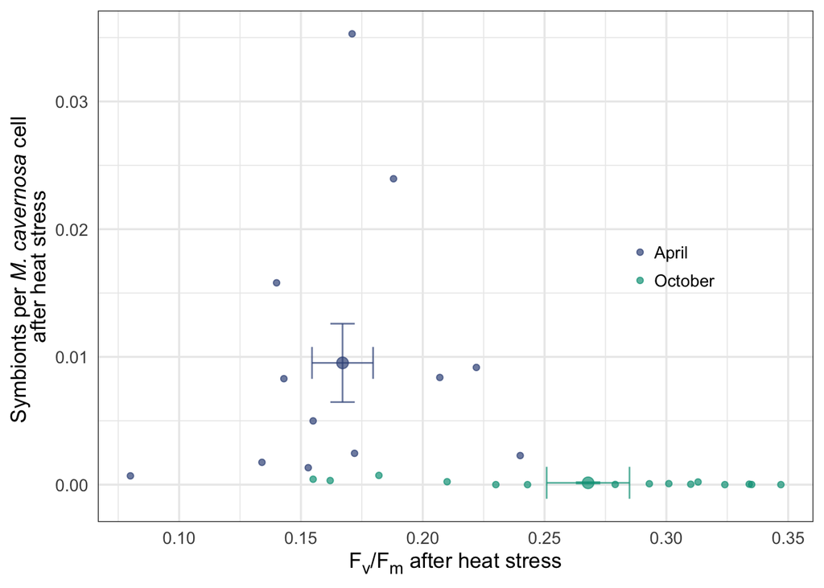

```r
mcavsensitivitysumm$sey2<-mcavsensitivitysey2$sey2
mcavsensitivitysumm$meany2<-mcavsensitivitymeany2$meany2


#UPDATES FOR ROSS:
#what if we try plotting end fv/fm and s:h rather than the relative change? And use prediction ellipses or mean and error bars rather than try to fit a linear model.

ggplot()+
  geom_point(data=mcavsensitivity,aes(x=post_y2,y=post_sh,colour=Batch))+
  geom_errorbar(data=mcavsensitivitysumm, aes(x=meany2,ymin=mean-se,ymax=mean+se, colour=Batch), width=0.01, show.legend=F)+
   geom_errorbar(data=mcavsensitivitysumm, aes(y=mean,xmin=meany2-sey2,xmax=meany2+sey2, colour=Batch), width=0.0025, show.legend=F)+
  geom_point(data=mcavsensitivitysumm, aes(x=meany2,y=mean,colour=Batch),size=3, show.legend=F)+
  theme_minimal(base_size = 13)%+replace%
    theme(panel.border = element_rect(colour='grey20',size=0.5,fill=NA))+
   scale_colour_manual(values=c('#3C5488B2','#00A087B2'),labels=c('April','October'))+
 theme(panel.spacing = unit(1.2, "lines"),legend.position = 'right')+
  theme(legend.title=element_text(size=0), axis.title.y = element_markdown(), axis.title.x=element_markdown())+
theme(legend.position = c(0.8,0.5))+
  labs(x='F<sub>v</sub>/F<sub>m</sub> after heat stress',y='Symbionts per *M. cavernosa* cell <br> after heat stress')
```

```r
  #ggsave('1d.seasonal_bleaching_sensitivity.pdf',device='pdf',width=7,height=5)
```

## SHUFFLING

### Figure 2: Inter- and intra-species variation in the shuffling towards durusdinium after recovery from heat stress.

Comparison of Proportion D before start of heat stress compared to two months into recovery. Data are binned at intervals of 0.02 (for variable Proportion D), and size aesthetic relates to number of cores in each bin to reduce overplotting. Data from April and October are both included here.

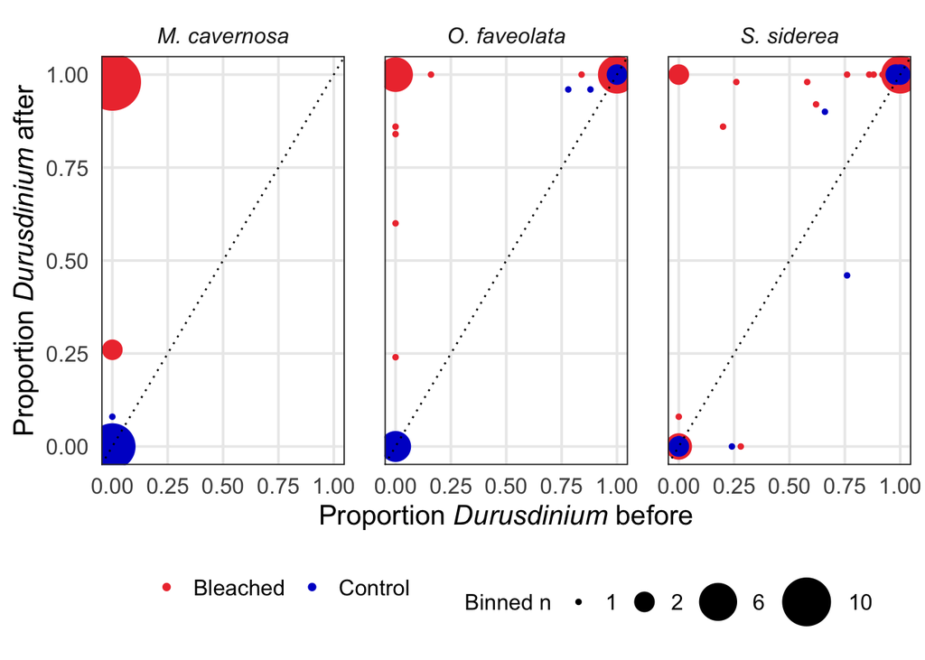

```r
mcavshift<-filter(mcav_wide_batches,!is.na(postDcat),!is.na(preDcat))
ofavshift<-filter(ofav_wide_batches,!is.na(postDcat),!is.na(preDcat))
ssidshift<-filter(ssid_wide_batches,!is.na(postDcat),!is.na(preDcat))
beforeaftershift<-rbind(mcavshift,ofavshift,ssidshift)
beforeaftershift$Treatment<-factor(beforeaftershift$Treatment,levels=c('Manipulated','Control'))
gaindd=expression(paste("Gained",italic(" Durusdinium")))
lostd=expression(paste("Lost",italic(" Durusdinium")))

   ggplot()+geom_count(data=(beforeaftershift),
     aes(x=preDcat,y=postDcat,colour=Treatment))+
facet_grid(cols=vars(Species),labeller=labeller(Species=Spec.labs))+
geom_abline(slope=1,intercept = 0,linetype='dotted')+
  scale_color_manual(values=c('brown2','blue3'),labels=c('Bleached','Control'))+
  theme_minimal(base_size = 15)%+replace%
    theme(panel.border = element_rect(colour='grey20',fill=NA),
          panel.grid.minor.x = element_blank(),
          panel.grid.minor.y = element_blank())+
  labs(x='Proportion *Durusdinium* before',y='Proportion *Durusdinium* after')+
 guides(size=guide_legend(title='Binned n'))+
  scale_size(range=c(1,14),breaks=(c(1,2,6,10)))+
  theme(axis.title.x = element_markdown(),axis.title.y=element_markdown())+
  theme(strip.text.x = element_text(face = 'italic'),
      panel.spacing = unit(1.5, "lines"), legend.position = 'bottom', legend.title=element_text(size=12))+
      guides(colour = guide_legend(title=''))
```

```r
#ggsave('2.before_after_durusdinium.pdf',device='pdf', width=10,height=5) #add 'gained durusdinium'/'lost durusdinium' labels
```

### Figure 3a: Shuffling towards high proportions of Durusdinium after heat stress recovery was greatest in M. cavernosa, followed by O. faveolata, followed by S. siderea.

Emulating the ‘symbiont shuffling’ plot to compare coral species, as in Cunning et al 2018 figure 3b. In order to be able to include mcav, which has no variation in initial proportion d, the following mcav models are independent of initial proportion d, then integrated in with the previous ofav & ssid predicted effects.

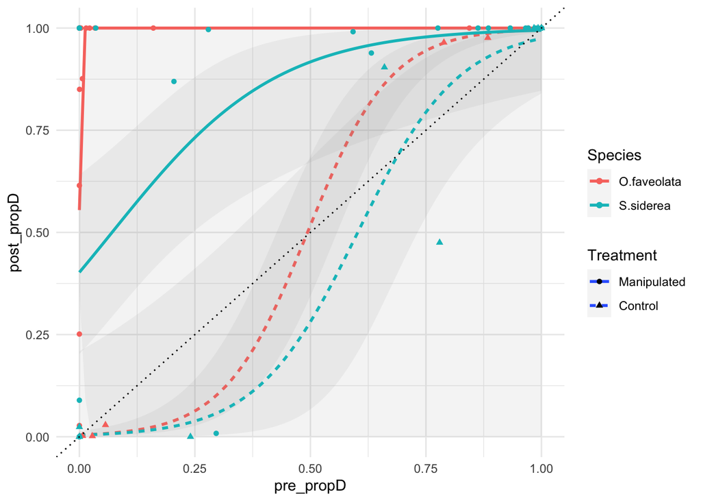

```r
shufflemod=glm(post_propD~pre_propD + Treatment*Species*Batch, data=filter(batches,batches$Species!='M.cavernosa'), family='quasibinomial')
#NB a mixed effects model cannot be used here, since a quasibinomial distribution is needed to bound this metric between -1 and 1.

# have a look at the data to see data distribution for the change in proportion Durusdinium
ggplot(data=filter(batches,batches$Species!='M.cavernosa'),aes(y=post_propD, x=pre_propD))+
  geom_smooth(aes(colour=Species, linetype=Treatment), method='glm',method.args = list(family = "quasibinomial"), alpha=0.1)+
  geom_point(aes(colour=Species, shape=Treatment))+
  geom_abline(slope=1,intercept = 0,linetype='dotted')+
  theme_minimal()
```

```r
summary(shufflemod)# Model summary
```

```
##
## Call:
## glm(formula = post_propD ~ pre_propD + Treatment * Species *
##     Batch, family = "quasibinomial", data = filter(batches, batches$Species !=
##     "M.cavernosa"))
##
## Deviance Residuals:
##      Min        1Q    Median        3Q       Max
## -1.99184  -0.11958   0.03595   0.24114   1.42314
##
## Coefficients:
##                                                Estimate Std. Error t value
## (Intercept)                                      0.9815     0.4578   2.144
## pre_propD                                        8.3438     1.9480   4.283
## TreatmentControl                                -4.8318     2.1137  -2.286
## SpeciesS.siderea                                -1.5428     0.6744  -2.288
## BatchOctober                                     0.1981     0.9471   0.209
## TreatmentControl:SpeciesS.siderea               -0.5660     2.1306  -0.266
## TreatmentControl:BatchOctober                   -0.8514     3.1201  -0.273
## SpeciesS.siderea:BatchOctober                   -0.6365     1.4792  -0.430
## TreatmentControl:SpeciesS.siderea:BatchOctober   3.7699     3.7441   1.007
##                                                Pr(>|t|)
## (Intercept)                                      0.0362 *
## pre_propD                                      7.01e-05 ***
## TreatmentControl                                 0.0259 *
## SpeciesS.siderea                                 0.0258 *
## BatchOctober                                     0.8350
## TreatmentControl:SpeciesS.siderea                0.7915
## TreatmentControl:BatchOctober                    0.7859
## SpeciesS.siderea:BatchOctober                    0.6686
## TreatmentControl:SpeciesS.siderea:BatchOctober   0.3182
## ---
## Signif. codes:  0 '***' 0.001 '**' 0.01 '*' 0.05 '.' 0.1 ' ' 1
##
## (Dispersion parameter for quasibinomial family taken to be 0.4056584)
##
##     Null deviance: 70.630  on 66  degrees of freedom
## Residual deviance: 24.508  on 58  degrees of freedom
##   (8 observations deleted due to missingness)
## AIC: NA
##
## Number of Fisher Scoring iterations: 8
```

```r
#treatment had significant effect on shuffling (p=0.0259). Batch did not significantly affect shuffling (p=0.8350).

#Get fitted values averaging across initial proportion durusdinium
eff <- effect(c('pre_propD', 'Species','Treatment'), shufflemod,
              xlevels=list(pre_propD=seq(0, 1, by=0.01)))
# Get all fitted values and subsets for each treatment
res <- droplevels(data.frame(eff))

res$Species <- factor(res$Species, levels=c("O.faveolata", "S.siderea"))
res.Bl <- subset(data.frame(eff), Treatment=="Manipulated")
res.Ct <- subset(data.frame(eff), Treatment=="Control")
# Get AUC for fitted values, lower and upper confidence limits
auc <- aggregate(res[, c("fit", "lower", "upper")],
                 by=list(Species=res$Species, Treatment=res$Treatment),
                 FUN=function(x) (mean(x)-0.5)/0.5)

auc.list <- split(auc, list(auc$Treatment))
auc$Treatment=factor(auc$Treatment, levels=c('Manipulated','Control'))
levels(auc$Treatment)<-c('Bleached','Control')
auc$Species=factor(auc$Species, levels=c('O.faveolata', 'S.siderea'))
```

```r
#using model independent of initial prop d for mcav
shufflemod2=lm(post_propD ~Treatment*Batch,
                 data=subset(batches, batches$Species=='M.cavernosa'))
summary(shufflemod2)
```

```
##
## Call:
## lm(formula = post_propD ~ Treatment * Batch, data = subset(batches,
##     batches$Species == "M.cavernosa"))
##
## Residuals:
##      Min       1Q   Median       3Q      Max
## -0.63488  0.00000  0.00129  0.08423  0.12081
##
## Coefficients:
##                               Estimate Std. Error t value Pr(>|t|)
## (Intercept)                    0.87919    0.04448  19.764  < 2e-16 ***
## TreatmentControl              -0.87919    0.08671 -10.139 8.19e-12 ***
## BatchOctober                   0.11952    0.06291   1.900    0.066 .
## TreatmentControl:BatchOctober -0.10086    0.12263  -0.822    0.417
## ---
## Signif. codes:  0 '***' 0.001 '**' 0.01 '*' 0.05 '.' 0.1 ' ' 1
##
## Residual standard error: 0.1664 on 34 degrees of freedom
##   (2 observations deleted due to missingness)
## Multiple R-squared:  0.8729, Adjusted R-squared:  0.8617
## F-statistic: 77.83 on 3 and 34 DF,  p-value: 2.631e-15
```

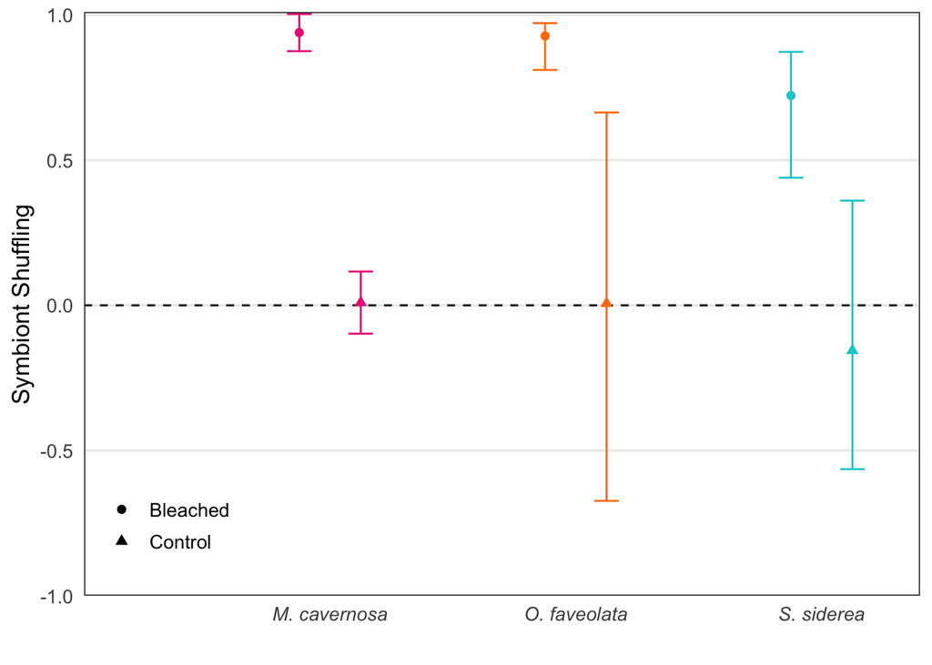

```r
#again for the initial durusdinium independent model, batch is not a significant driver of shuffling, p= 0.066.  This model did not fit a quasibinomial distrubution, but is amost entirely bond between 0 and 1 regardless due to very large effect size & minimal variation in the data.

#ggplot(data=filter(batches,batches$Species=='M.cavernosa'),aes(y=post_propD, x=Treatment))+
  #geom_point(aes(shape=Treatment))+
 # theme_minimal()

eff2 <- effect(c('Treatment'), shufflemod2)

# Get all fitted values and subsets for each treatment level
res2 <- droplevels(data.frame(eff2))

res2.Bl <- subset(data.frame(eff2), Treatment=="Manipulated")
res2.Ct <- subset(data.frame(eff2), Treatment=="Control")
# Get AUC for fitted values, lower and upper confidence limits
auc2 <- aggregate(res2[, c("fit", "lower", "upper")],
                 by=list(Treatment=res2$Treatment),
                 FUN=function(x) (mean(x)))
levels(auc2$Treatment)<-c('Control','Bleached')
auc2.list <- split(auc2, list(auc2$Treatment))
auc2$Species=factor(rep('M.cavernosa'))

speciesshuff<-rbind(auc,auc2)
speciesshuff$Species=factor(speciesshuff$Species, levels=c('M.cavernosa', 'O.faveolata', 'S.siderea'))

#quote the shuffling metric for bleached cores of each species, 'S': mcav=0.938948279, ofav=0.927486547, ssid=0.722313707.

ggplot(data=speciesshuff)+
  geom_hline(yintercept=0,linetype='dashed')+
  geom_errorbar(aes(ymin=lower, ymax=upper, x=Species, colour=Species, group=Treatment),size=0.5, position=position_dodge(width=0.5), width=0.2)+
   geom_point(aes(y=fit, x=Species,shape=Treatment, colour=Species),size=2, position=position_dodge(width=0.5))+
  theme_minimal(base_size = 13)%+replace%
   theme(panel.border = element_rect(colour='grey20',fill=NA),
          panel.grid.minor.x = element_blank(),
         panel.grid.major.x = element_blank(),
          panel.grid.minor.y = element_blank())+
  scale_color_manual(values=c('deeppink2','darkorange1', 'darkturquoise'))+
  guides(colour=F, shape=guide_legend(title=''))+
  theme(legend.position=c(0.1,0.15))+
  labs(y='Symbiont Shuffling', x='')+
  scale_y_continuous(limits=c(-1,1.01),expand=c(0,0))+
   scale_x_discrete(labels=c(mcav,ofav,ssid), expand=expansion(mult=c(0.5,0.2)))
```

```r
#ggsave('3a.treatment_shuffling.pdf',device='pdf', width=7,height=5)
#add 'more durusdinium/less durusdinium' labels post-save
```

## Shuffling and photochemical efficiency

### Differnet photochemical disadvantages of hosting Durusdinium at ambient temperatures cannot explain the difference in shuffling between O. faveolata and S. siderea.

Recreating Cunning et al 2018 test of the relative photochemical disadvantages of hosting durusdinium at ambient temperatures to explain species hierarchy (ofav>ssid) in shuffling.

```r
ipam=filter(allbleach,allbleach$Timepoint=='Pre-bleach',allbleach$Species!='M.cavernosa')

ipaminitmod=lmer(Y2~PropD*Species*Batch+(1|Colony),data=ipam)
#plot_resqq(ipaminitmod)
summary(ipaminitmod)
```

```
## Linear mixed model fit by REML. t-tests use Satterthwaite's method [
## lmerModLmerTest]
## Formula: Y2 ~ PropD * Species * Batch + (1 | Colony)
##    Data: ipam
##
## REML criterion at convergence: -203.3
##
## Scaled residuals:
##      Min       1Q   Median       3Q      Max
## -1.86465 -0.49506 -0.03011  0.50441  1.80649
##
## Random effects:
##  Groups   Name        Variance  Std.Dev.
##  Colony   (Intercept) 0.0001145 0.01070
##  Residual             0.0002989 0.01729
## Number of obs: 51, groups:  Colony, 19
##
## Fixed effects:
##                                 Estimate Std. Error         df t value Pr(>|t|)
## (Intercept)                    0.5293324  0.0070538 25.0437420  75.042  < 2e-16
## PropD                         -0.0032823  0.0134075 27.9645585  -0.245 0.808391
## SpeciesS.siderea               0.0001896  0.0108844 26.2466965   0.017 0.986235
## Batch2                         0.0363517  0.0096538 37.8622808   3.766 0.000564
## PropD:SpeciesS.siderea        -0.0216401  0.0186729 31.1020055  -1.159 0.255317
## PropD:Batch2                  -0.0017877  0.0163661 33.5505728  -0.109 0.913669
## SpeciesS.siderea:Batch2       -0.0099099  0.0158472 33.9985376  -0.625 0.535923
## PropD:SpeciesS.siderea:Batch2 -0.0053723  0.0239426 32.1793643  -0.224 0.823879
##
## (Intercept)                   ***
## PropD
## SpeciesS.siderea
## Batch2                        ***
## PropD:SpeciesS.siderea
## PropD:Batch2
## SpeciesS.siderea:Batch2
## PropD:SpeciesS.siderea:Batch2
## ---
## Signif. codes:  0 '***' 0.001 '**' 0.01 '*' 0.05 '.' 0.1 ' ' 1
##
## Correlation of Fixed Effects:
##             (Intr) PropD  SpcsS. Batch2 PrD:SS. PrD:B2 SS.:B2
## PropD       -0.554
## SpecisS.sdr -0.648  0.359
## Batch2      -0.517  0.289  0.335
## PrpD:SpcsS.  0.398 -0.718 -0.621 -0.207
## PropD:Btch2  0.317 -0.564 -0.205 -0.634  0.405
## SpcsS.sd:B2  0.315 -0.176 -0.420 -0.609  0.246   0.386
## PrpD:SS.:B2 -0.217  0.386  0.312  0.434 -0.526  -0.684 -0.731
```

```r
#UPDATE FOR ROSS: No significant differnece in the interaction between proportion durusdinium and coral species on Fv/Fm (p=0.255).
```

### Figure S1: Despite greater symbiont loss in the October M. cavernosa corals, shuffling between April and October were similar for all three coral species.

```r
#before getting fitted values, test statistical significance of batch for each species inidivually:
ofavbatchmod=glm(post_propD ~ pre_propD+Batch,
                 data=filter(batches, batches$Species=='O.faveolata', Treatment=='Manipulated'), family='quasibinomial')
ssidbatchmod=glm(post_propD ~ pre_propD + Batch,
                 data=filter(batches, batches$Species=='S.siderea', Treatment=='Manipulated'),family='quasibinomial')
mcavbatchmod=lm(post_propD ~Batch,
                 data=filter(batches, batches$Species=='M.cavernosa', Treatment=='Manipulated'))
summary(ofavbatchmod) #p=0.683
```

```
##
## Call:
## glm(formula = post_propD ~ pre_propD + Batch, family = "quasibinomial",
##     data = filter(batches, batches$Species == "O.faveolata",
##         Treatment == "Manipulated"))
##
## Deviance Residuals:
##     Min       1Q   Median       3Q      Max
## -1.2216   0.0000   0.0000   0.1365   1.1338
##
## Coefficients:
##              Estimate Std. Error t value Pr(>|t|)
## (Intercept)    0.1034     0.5202   0.199    0.845
## pre_propD    695.2104   487.7503   1.425    0.170
## BatchOctober   0.4101     0.9890   0.415    0.683
##
## (Dispersion parameter for quasibinomial family taken to be 0.3314469)
##
##     Null deviance: 14.570  on 21  degrees of freedom
## Residual deviance:  7.007  on 19  degrees of freedom
##   (3 observations deleted due to missingness)
## AIC: NA
##
## Number of Fisher Scoring iterations: 15
```

```r
summary(ssidbatchmod) #p=0.9768
```

```
##
## Call:
## glm(formula = post_propD ~ pre_propD + Batch, family = "quasibinomial",
##     data = filter(batches, batches$Species == "S.siderea", Treatment ==
##         "Manipulated"))
##
## Deviance Residuals:
##     Min       1Q   Median       3Q      Max
## -1.6993   0.1044   0.1079   0.1944   1.3517
##
## Coefficients:
##              Estimate Std. Error t value Pr(>|t|)
## (Intercept)  -0.40083    0.53355  -0.751   0.4605
## pre_propD     5.57625    2.20431   2.530   0.0191 *
## BatchOctober  0.03385    1.14948   0.029   0.9768
## ---
## Signif. codes:  0 '***' 0.001 '**' 0.01 '*' 0.05 '.' 0.1 ' ' 1
##
## (Dispersion parameter for quasibinomial family taken to be 0.4851499)
##
##     Null deviance: 23.231  on 24  degrees of freedom
## Residual deviance: 12.690  on 22  degrees of freedom
##   (5 observations deleted due to missingness)
## AIC: NA
##
## Number of Fisher Scoring iterations: 7
```

```r
summary(mcavbatchmod) #p=0.107
```

```
##
## Call:
## lm(formula = post_propD ~ Batch, data = filter(batches, batches$Species ==
##     "M.cavernosa", Treatment == "Manipulated"))
##
## Residuals:
##      Min       1Q   Median       3Q      Max
## -0.63488  0.00062  0.00129  0.11015  0.12081
##
## Coefficients:
##              Estimate Std. Error t value Pr(>|t|)
## (Intercept)   0.87919    0.05068  17.348 8.19e-16 ***
## BatchOctober  0.11952    0.07167   1.668    0.107
## ---
## Signif. codes:  0 '***' 0.001 '**' 0.01 '*' 0.05 '.' 0.1 ' ' 1
##
## Residual standard error: 0.1896 on 26 degrees of freedom
##   (2 observations deleted due to missingness)
## Multiple R-squared:  0.09662,    Adjusted R-squared:  0.06187
## F-statistic: 2.781 on 1 and 26 DF,  p-value: 0.1074
```

```r
eff <- effect(c('pre_propD', 'Species','Treatment', 'Batch'), shufflemod,
              xlevels=list(pre_propD=seq(0, 1, by=0.01)))
# Get all fitted values and subsets for each treatment and now also batch
res <- droplevels(data.frame(eff))

res$Species <- factor(res$Species, levels=c("O.faveolata", "S.siderea"))
res.Bl <- subset(data.frame(eff), Treatment=="Manipulated")
res.Ct <- subset(data.frame(eff), Treatment=="Control")
res.Ap<- subset(data.frame(eff), Batch=='April')
res.Oc<- subset(data.frame(eff), Batch=='October')
# Get AUC for fitted values, lower and upper confidence limits
auc <- aggregate(res[, c("fit", "lower", "upper")],
                 by=list(Species=res$Species, Treatment=res$Treatment, Batch=res$Batch),
                 FUN=function(x) (mean(x)-0.5)/0.5)

auc$Treatment=factor(auc$Treatment, levels=c('Manipulated','Control'))
levels(auc$Treatment)<-c('Bleached','Control')
auc$Species=factor(auc$Species, levels=c('O.faveolata', 'S.siderea'))
auc$Batch=factor(auc$Batch, levels=c('April','October'))



eff2 <- effect(c('Treatment','Batch'), shufflemod2)
```

```
## NOTE: TreatmentBatch is not a high-order term in the model
```

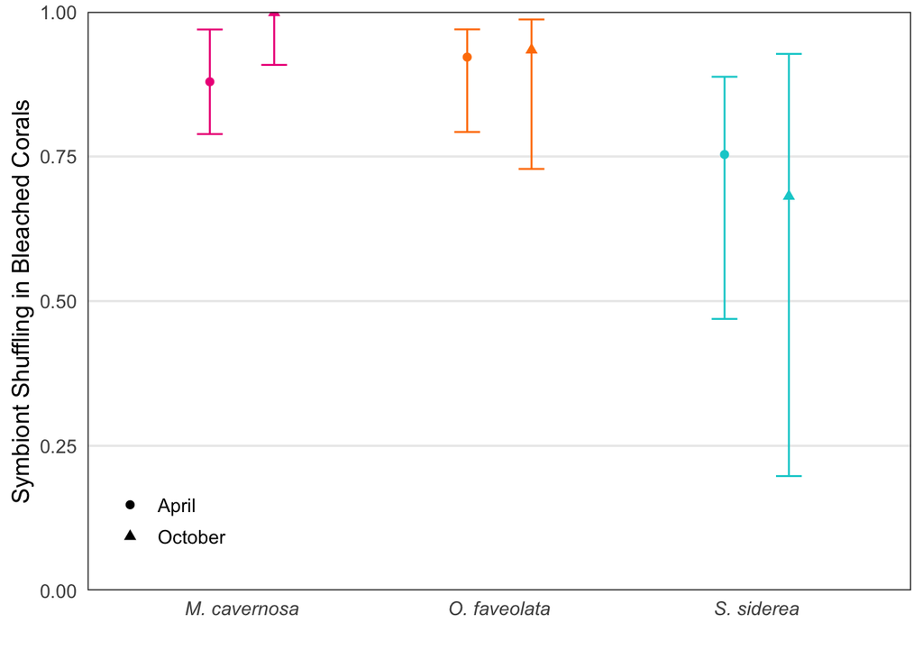

```r
res2 <- droplevels(data.frame(eff2))
res2.Bl <- subset(data.frame(eff2), Treatment=="Manipulated")
res2.Ct <- subset(data.frame(eff2), Treatment=="Control")
res2.Ap<- subset(data.frame(eff2), Batch=='April')
res2.Oc<- subset(data.frame(eff2), Batch=='October')

# Get AUC for fitted values, lower and upper confidence limits
auc2 <- aggregate(res2[, c("fit", "lower", "upper")],
                 by=list(Treatment=res2$Treatment, Batch=res2$Batch),
                 FUN=function(x) (mean(x)))
levels(auc2$Treatment)<-c('Control','Bleached')
auc2$Species=factor(rep('M.cavernosa'))
batchshuff<- rbind(auc2, auc)
batchshuff$spbatch<- interaction (batchshuff$Batch,batchshuff$Species)

ggplot(data=filter(batchshuff,batchshuff$Treatment=='Bleached'))+
  geom_errorbar(aes(ymin=lower, ymax=upper, x=Species, colour=Species, group=Batch),size=0.5, position=position_dodge(width=0.5), width=0.2)+
   geom_point(aes(y=fit, x=Species, shape=Batch, colour=Species),size=2, position=position_dodge(width=0.5))+
  theme_minimal(base_size = 13)%+replace%
   theme(panel.border = element_rect(colour='grey20',fill=NA),
          panel.grid.minor.x = element_blank(),
         panel.grid.major.x = element_blank(),
          panel.grid.minor.y = element_blank())+
  scale_color_manual(values=c('deeppink2','darkorange1', 'darkturquoise'))+scale_x_discrete(labels=c(mcav,ofav,ssid))+
  guides(colour=F, shape=guide_legend(title=''))+
  theme(legend.position=c(0.1,0.15))+
  labs(y='Symbiont Shuffling in Bleached Corals', x='')+
coord_cartesian(clip='on', ylim=c(0,1.0))+
  scale_y_continuous(expand=c(0,0))
```

```r
#ggsave('S1.shuffling_batches.pdf',device='pdf',width=7,height=5)
```

### Figure 3b: Shuffling occurred later in recovery in M. cavernosa compared to O. faveolata and S. siderea.

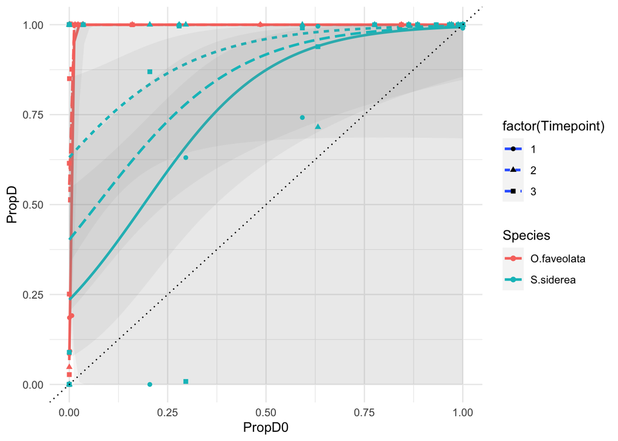

```r
shuffletimes=read.csv('shuffle_timepoints.csv',header =T)
shuffletimes$Treatment=factor(shuffletimes$Treatment)
shuff=read.csv('shuff.csv',header = T)
shuff$Colony=factor(shuff$Colony)
shuff$Species=factor(shuff$Species)
shuff$Timepoint=as.integer(shuff$Timepoint,length=3)

# have a look at the data to see data distribution for the change in proportion Durusdinium
ggplot(data=filter(shuff,shuff$Species!='M.cavernosa'),aes(y=PropD, x=PropD0))+
  geom_smooth(aes(colour=Species, linetype=factor(Timepoint)), method='glm',method.args = list(family = "quasibinomial"), alpha=0.1)+
  geom_point(aes(colour=Species, shape=factor(Timepoint)))+
  geom_abline(slope=1,intercept = 0,linetype='dotted')+
  theme_minimal()
```

```r
shuffmod=glm(PropD~PropD0+Species*Timepoint,data=filter(shuff, shuff$Species!='M.cavernosa'), family='quasibinomial')
summary(shuffmod)
```

```
##
## Call:
## glm(formula = PropD ~ PropD0 + Species * Timepoint, family = "quasibinomial",
##     data = filter(shuff, shuff$Species != "M.cavernosa"))
##
## Deviance Residuals:
##      Min        1Q    Median        3Q       Max
## -1.93613  -0.07129   0.06986   0.56984   1.43474
##
## Coefficients:
##                            Estimate Std. Error t value Pr(>|t|)
## (Intercept)                 -1.6604     0.6125  -2.711 0.007623 **
## PropD0                       6.6233     1.4531   4.558 1.18e-05 ***
## SpeciesS.siderea             0.6491     1.0954   0.593 0.554508
## Timepoint                    1.0516     0.3087   3.407 0.000877 ***
## SpeciesS.siderea:Timepoint  -0.7745     0.4916  -1.576 0.117568
## ---
## Signif. codes:  0 '***' 0.001 '**' 0.01 '*' 0.05 '.' 0.1 ' ' 1
##
## (Dispersion parameter for quasibinomial family taken to be 0.4984103)
##
##     Null deviance: 125.769  on 133  degrees of freedom
## Residual deviance:  73.193  on 129  degrees of freedom
##   (29 observations deleted due to missingness)
## AIC: NA
##
## Number of Fisher Scoring iterations: 7
```

```r
anova(shuffmod,test='F')
```

```
## Analysis of Deviance Table
##
## Model: quasibinomial, link: logit
##
## Response: PropD
##
## Terms added sequentially (first to last)
##
##
##                   Df Deviance Resid. Df Resid. Dev       F    Pr(>F)
## NULL                                133    125.769
## PropD0             1   43.995       132     81.774 88.2707 2.711e-16 ***
## Species            1    1.705       131     80.069  3.4219  0.066626 .
## Timepoint          1    5.637       130     74.432 11.3095  0.001015 **
## Species:Timepoint  1    1.239       129     73.193  2.4863  0.117290
## ---
## Signif. codes:  0 '***' 0.001 '**' 0.01 '*' 0.05 '.' 0.1 ' ' 1
```

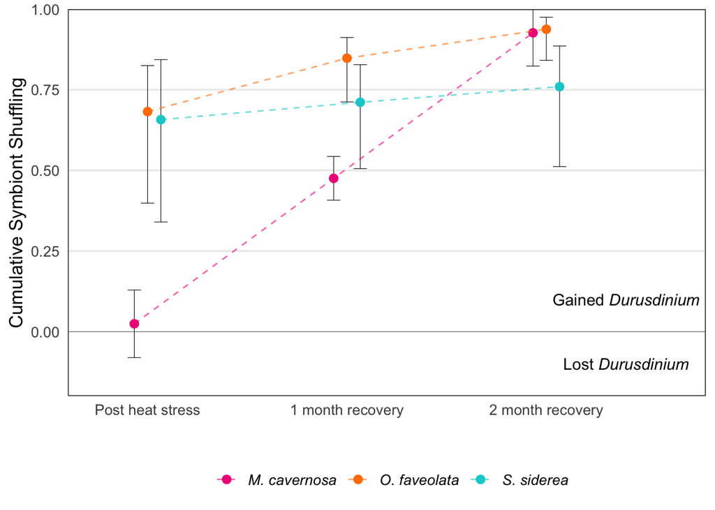

```r
propD1=glm(PropD ~ PropD0+Timepoint*Species,
             data=filter(shuff, shuff$Species!='M.cavernosa'), family='quasibinomial')

eff1 <- effect(c('PropD0', 'Timepoint', 'Species'), propD1,
              xlevels=list(PropD0=seq(0, 1, by=0.01)))

res <- droplevels(data.frame(eff1))
res$Species <- factor(res$Species, levels=c("O.faveolata", "S.siderea"))
res$Timepoint <- factor(res$Timepoint,levels=c('1','2','3'))
# Get AUC for fitted values, lower and upper confidence limits
auc1 <- aggregate(res[, c("fit", "lower", "upper")],
                 by=list(Species=res$Species,Timepoint=res$Timepoint),
                 FUN=function(x) (mean(x)-0.5)/0.5)

#now an intial prop d independent model for mcav
propD2=lm(PropD ~ Timepoint,data=filter(shuff, shuff$Species=='M.cavernosa'))

eff2 <- effect(c('Timepoint'), propD2)

res <- droplevels(data.frame(eff2))
res$Timepoint <- factor(res$Timepoint,levels=c('1','2','3'))
# Get AUC for fitted values, lower and upper confidence limits
auc2 <- aggregate(res[, c("fit", "lower", "upper")],
                 by=list(Timepoint=res$Timepoint),
                 FUN=function(x) (mean(x)))
auc2$Species=factor(rep('M.cavernosa'))

aucall <- rbind(auc1, auc2)
aucall$Timepoint=factor(aucall$Timepoint, levels=c(1,2,3))
aucall$Species=factor(aucall$Species, levels=c('M.cavernosa','O.faveolata','S.siderea'))

##########
ofav=expression(paste(italic("O. faveolata")))
ssid=expression(paste(italic("S. siderea")))
mcav=expression(paste(italic("M. cavernosa")))

ggplot(aucall, aes(x = Timepoint, y = fit, group = Species)) +
  geom_errorbar(data=aucall, aes(ymin = lower, ymax = upper),
                position = position_dodge(0.2), lwd = 0.2, width = 0.2) +
  geom_point(aes(color = Species),
             position = position_dodge(0.2), size = 2.5)+
  geom_hline(yintercept = 0, lwd = 0.1) +
  scale_x_discrete(labels=c('Post heat stress','1 month recovery','2 month recovery'),expand=expansion(mult=c(0.2,0.4)))+
  theme_minimal(base_size = 13)%+replace%
   theme(panel.border = element_rect(colour='grey20',fill=NA),
          panel.grid.minor.x = element_blank(),
         panel.grid.major.x = element_blank(),
          panel.grid.minor.y = element_blank())+
  geom_line(linetype='dashed',alpha=0.6,aes(colour=Species),position = position_dodge(0.2))+
  scale_colour_manual(values=c('deeppink2','darkorange1','darkturquoise'),labels=c(mcav,ofav,ssid), name='')+
  coord_cartesian(clip='on', ylim=c(-.2,1.0))+
  labs(y='Cumulative Symbiont Shuffling',x='')+
  annotate(geom='text',x=3.4,y=0.1,label=gaindd,size=4)+
   annotate(geom='text',x=3.4,y=-0.1,label=lostd,size=4)+
  theme(legend.position = 'bottom')+
  scale_y_continuous(expand=c(0,0))
```

```r
#ggsave('3b.shuffling_cumulative.pdf',device='pdf',height=5,width=7)

###UPDATE FOR ROSS: The predicted values are based of a model which controls for pre-heat stress proportion durusdinium (rather than proportion durusdinium at the previous timepoint). Making 'timepoint' an integer rather than a factor in the model also changed things. Would like to perform stats on the interaction effect on shuffling between timepoint and species, but unsure how since mcav fitted to a separate model. The '2-month recovery' points are very slightly differnet from those in the bleached Vs control shuffling plot, but I think this is indicative of shuffling at each timepoint being linked to each coral (rather than averaged within each species) for these predicted values, rather than a mistake in the code.
```

### Figure 3c: O. faveolata and S.siderea corals that initially hosted background Durusdinium shuffled more quickly and more fully to Durusdinium than those with no initial Durusdinium, which shuffled less than M.cavernosa that contained no initial Durusdinium.

```r
#now look at timing for switching and shuffling
shufflegroups<- filter(shuffletimes,shuffletimes$Treatment=='Manipulated')
shufflegroups$initiald<-paste(shufflegroups$PropD1)
shufflegroups<-filter(shufflegroups,shufflegroups$initiald!='NA')
shufflegroups$initiald[shufflegroups$Species=='M.cavernosa' & shufflegroups$PropD1==0]='MC0'
shufflegroups$initiald[shufflegroups$Species!='M.cavernosa' & shufflegroups$PropD1==0]='OFSS0'
shufflegroups$initiald[shufflegroups$Species!='M.cavernosa' & shufflegroups$PropD1>0]='OFSS0TO50'
shufflegroups$initiald[shufflegroups$Species!='M.cavernosa' & shufflegroups$PropD1>0.50]='OFSS50TO100'
shufflegroups$initiald=factor(shufflegroups$initiald, levels=c('MC0','OFSS0','OFSS0TO50','OFSS50TO100'))
shufflegroups<-filter(shufflegroups,shufflegroups$initiald!='NA')

shuffmod4=glmer(PropD4~initiald+(1|Colony),data=shufflegroups, family='binomial')
summary(shuffmod4)
```

```
## Generalized linear mixed model fit by maximum likelihood (Laplace
##   Approximation) [glmerMod]
##  Family: binomial  ( logit )
## Formula: PropD4 ~ initiald + (1 | Colony)
##    Data: shufflegroups
##
##      AIC      BIC   logLik deviance df.resid
##     47.3     58.8    -18.6     37.3       69
##
## Scaled residuals:
##     Min      1Q  Median      3Q     Max
## -399.86    0.00    0.03    0.23    1.13
##
## Random effects:
##  Groups Name        Variance Std.Dev.
##  Colony (Intercept) 0.6595   0.8121
## Number of obs: 74, groups:  Colony, 29
##
## Fixed effects:
##                     Estimate Std. Error z value Pr(>|z|)
## (Intercept)           2.8589     1.1892   2.404   0.0162 *
## initialdOFSS0        -3.1753     1.3664  -2.324   0.0201 *
## initialdOFSS0TO50    -0.2725     1.4253  -0.191   0.8484
## initialdOFSS50TO100  15.3343    10.9736   1.397   0.1623
## ---
## Signif. codes:  0 '***' 0.001 '**' 0.01 '*' 0.05 '.' 0.1 ' ' 1
##
## Correlation of Fixed Effects:
##             (Intr) inOFSS0 iOFSS0T
## initldOFSS0 -0.855
## inOFSS0TO50 -0.568  0.496
## iOFSS50TO10  0.003 -0.002   0.007
```

```r
# prop d significantly higher after mcav switching compared to ofav/ssid switching p=0.02**

shufflegroups= pivot_longer(data=shufflegroups, cols=starts_with('PropD'),
               names_to='Timepoint', names_prefix='PropD', values_to='PropD',
               values_drop_na=T)
#confirm that ofav and ssid can reasonably be grouped together:
shufflegroups$Species<-as.factor(shufflegroups$Species)
shufflegroups$Timepoint<-as.numeric(shufflegroups$Timepoint)
shufflegroups$Colony<-as.factor(shufflegroups$Colony)
ofavssidpropd<- lmer(PropD~Timepoint*initiald*Species+(1|Colony),data=filter(shufflegroups,shufflegroups$Species!='M.cavernosa'))
summary(ofavssidpropd)#no significant effcet of ofav vs ssid on prop d (p=0.45), nor of time-species interaction (p=0.33)
```

```
## Linear mixed model fit by REML. t-tests use Satterthwaite's method [
## lmerModLmerTest]
## Formula: PropD ~ Timepoint * initiald * Species + (1 | Colony)
##    Data: filter(shufflegroups, shufflegroups$Species != "M.cavernosa")
##
## REML criterion at convergence: 50.3
##
## Scaled residuals:
##     Min      1Q  Median      3Q     Max
## -3.5537 -0.5706  0.0411  0.2170  2.7553
##
## Random effects:
##  Groups   Name        Variance Std.Dev.
##  Colony   (Intercept) 0.006219 0.07886
##  Residual             0.058042 0.24092
## Number of obs: 185, groups:  Colony, 19
##
## Fixed effects:
##                                                 Estimate Std. Error        df
## (Intercept)                                     -0.22142    0.11442 119.04300
## Timepoint                                        0.19872    0.04066 152.80815
## initialdOFSS0TO50                                0.13538    0.15441 152.26788
## initialdOFSS50TO100                              1.17355    0.16101 108.96067
## SpeciesS.siderea                                 0.12907    0.17330 113.87593
## Timepoint:initialdOFSS0TO50                      0.10723    0.05500 153.08338
## Timepoint:initialdOFSS50TO100                   -0.19179    0.05572 152.20207
## Timepoint:SpeciesS.siderea                      -0.05788    0.05959 153.46583
## initialdOFSS0TO50:SpeciesS.siderea               0.15157    0.25239 159.31473
## initialdOFSS50TO100:SpeciesS.siderea            -0.20809    0.22291 115.43250
## Timepoint:initialdOFSS0TO50:SpeciesS.siderea    -0.05943    0.08846 152.73594
## Timepoint:initialdOFSS50TO100:SpeciesS.siderea   0.07848    0.07611 152.80261
##                                                t value Pr(>|t|)
## (Intercept)                                     -1.935 0.055348 .
## Timepoint                                        4.887 2.56e-06 ***
## initialdOFSS0TO50                                0.877 0.382004
## initialdOFSS50TO100                              7.289 5.26e-11 ***
## SpeciesS.siderea                                 0.745 0.457942
## Timepoint:initialdOFSS0TO50                      1.950 0.053043 .
## Timepoint:initialdOFSS50TO100                   -3.442 0.000745 ***
## Timepoint:SpeciesS.siderea                      -0.971 0.332919
```

[output cut: 17 more lines]

```
## iOFSS50TO100:   0.513 -0.439 -0.383      -0.722        -0.774  0.329
## T:OFSS0TO50:   -0.394  0.460  0.538       0.283         0.567 -0.622
## T:OFSS50TO100: -0.457  0.534  0.339       0.621         0.659 -0.395
##                Tm:OFSS50TO100 Tm:SS. iOFSS0TO50: iOFSS50TO100: T:OFSS0TO50:
## Timepoint
## inOFSS0TO50
## inOFSS50TO100
## SpecisS.sdr
## Tm:OFSS0TO50
## Tm:OFSS50TO100
## Tmpnt:SpcS.     0.498
## iOFSS0TO50:     0.284          0.580
## iOFSS50TO100:   0.612          0.655  0.540
## T:OFSS0TO50:   -0.335         -0.674 -0.866      -0.444
## T:OFSS50TO100: -0.732         -0.783 -0.454      -0.844         0.527
```

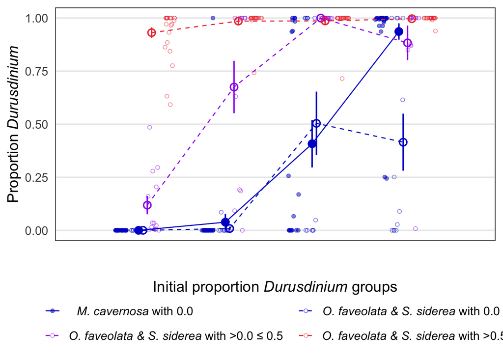

```r
MCswitchex=expression(paste( italic("M. cavernosa "),'with 0.0                             '))
OFSSswitchex=expression(paste( italic("O. faveolata & S. siderea "),'with 0.0  '))
OFSSshuffex1=expression(paste( italic("O. faveolata & S. siderea "),'with >0.0 ≤ 0.5  '))
OFSSshuffex2=expression(paste( italic("O. faveolata & S. siderea "),'with >0.5'))


ggplot(shufflegroups, aes(x = Timepoint, y = PropD, group=initiald)) +
  geom_point(aes(colour=initiald, shape=initiald),
             position = position_jitterdodge(), alpha=0.5) +
  stat_summary(aes(colour=initiald, shape=initiald),fun.data='mean_se',
             position = position_dodge(0.2), size=0.7,show.legend =F) +
  scale_x_discrete(labels=c('Pre heat stress','Post heat stress','1 month recovery','2 month recovery'))+
  stat_summary(geom='line', aes(linetype=initiald, colour=initiald),position = position_dodge(0.2))+
  theme_minimal(base_size = 15)%+replace%
   theme(panel.border = element_rect(colour='grey20',fill=NA),
          panel.grid.minor.x = element_blank(),
         panel.grid.major.x = element_blank(),
          panel.grid.minor.y = element_blank())+
  scale_linetype_manual(values=c('solid','dashed','dashed','dashed'),labels=c(MCswitchex,OFSSswitchex,OFSSshuffex1, OFSSshuffex2), name='Initial proportion *Durusdinium* groups')+
  scale_shape_manual(values=c(19,1,1,1),labels=c(MCswitchex,OFSSswitchex,OFSSshuffex1, OFSSshuffex2), name='Initial proportion *Durusdinium* groups')+
  scale_colour_manual(values=c('blue3','blue3','purple','brown2'),labels=c(MCswitchex,OFSSswitchex,OFSSshuffex1, OFSSshuffex2),name='Initial proportion *Durusdinium* groups')+
  labs(y="Proportion *Durusdinium*", x='')+
  guides(colour=guide_legend(nrow=2, byrow=TRUE, title.position ='top',title.hjust = 0.5),linetype=guide_legend(nrow=2, byrow=TRUE, title.position ='top',title.hjust = 0.5))+
  theme(legend.position = 'bottom', legend.title=element_markdown(), axis.title.y = element_markdown())
```

```r
#ggsave('3c.initial_durusdinium_shuffling.pdf',device='pdf',height=5,width=7)

###UPDATE FOR ROSS: Due to small sample size, ofav and ssid are grouped together here (model finds no significant effect of species). Now this plot includes all corals.
```